# Photochemcad 2.0 🔅

[Old website](http://www.photochemcad.com/photochemcad_server_backup_20180814/index.html) for photochemcad is a static version with hundreds of pages built mannually and no backend database. The new version [Photochemcad 2.0](http://www.photochemcad.com/) started from scratch, used modern web responsive design and built both front-end as well as back-end. All 339 compounds’ information were migrated to MySQL tables, including data source from excel files as well as web scraping from the old website via *XPath* by Python.

## Technology Stack

PHP, MySQL, HTML5, CSS3, JQuery, AJAX, Echarts, Responsive Layout, XAMPP.

## Design Process

This website’s stakeholder is Professor Jonathan Lindsey and his team, and target users are mainly chemists in photochem fields. In the design process, I put users in the first place, abandoned bulky styles and only emphasize important information in the straightforward and academic way. Also, I followed rule of agile development, adjusting website style as well as functiosn as the requirements from the stakeholder evolved.

## Website at A Glance

1. Homepage. This page was initially designed without the four cards below because this may cause repetition with the navigation bar. While the stakeholder required to use this way to emphasize.

[figure not shown]

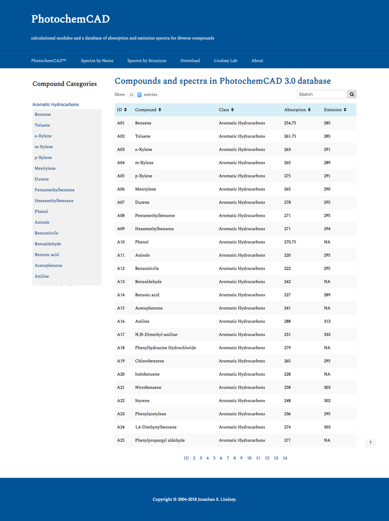

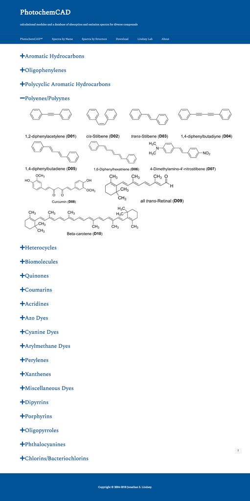

4. Compound detail. This part was initially designed as a partial refresh of the page by *AJAX* while the stakeholder requested to have different urls for each compound so that users can cite a certain compound by the link. As the result, compound name is included in the url and used as a *$_GET* parameter.

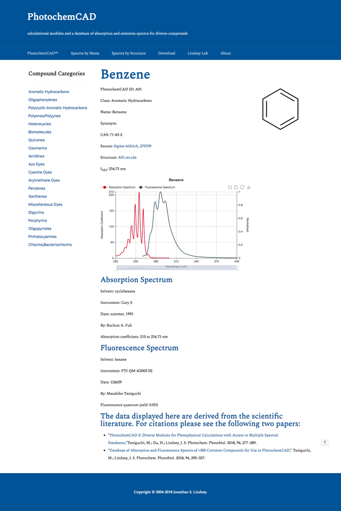

5. Compound spectrum. The absorption spectrum and fluorescence spectrum are combined into one graph based on ECharts JavaScript library.

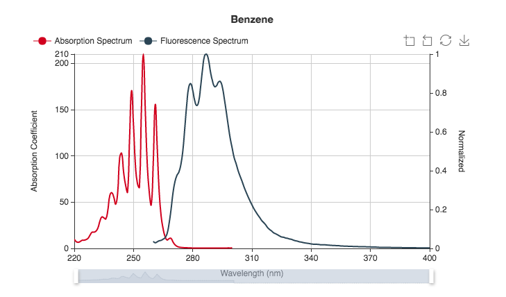

- Download. This page provides download link as well as install guidance for PhotochemCAD™.

[figure not shown]

- About. This page introduces backgrdound and version history for PhotochemCAD™.

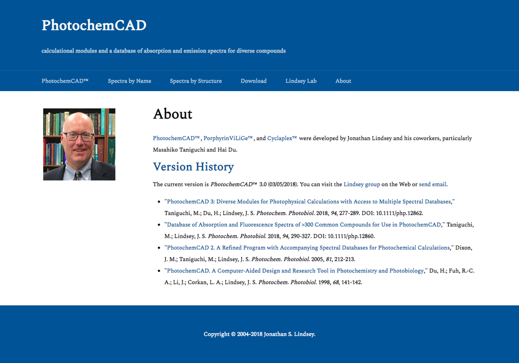

## Paper

A paper *Developing a user community in the photosciences.A website for spectral data and access to PhotochemCAD* will be published on [SPIE](http://spie.org/). Yaxue Guo and Zhen Xu are first co-authors. Ann Elizabeth Norcross, Masahiko Taniguchi, and Jonathan S. Lindsey are second co-authors. There will be a poster presentation on Feb 2019 at San Francisco.

## Authors

- **Yaxue Guo** designed, developed and deployed the whole website except for the spectrum chart, and integrated the spectrum chart into the compound detail page. No front-end framework neither PHP framework used. All code started from scratch.
- **Zhen Xu** developed the spectrum chart for the compound detail page using ECharts library.

## Acknowledgement

- PhotochemCAD™, PorphyrinViLiGe™, and Cyclaplex™ were developed by Jonathan Lindsey and his coworkers, particularly Masahiko Taniguchi and Hai Du. All data used in this website is credit to Professor [Jonathan Lindsey’s Lab](https://sites.google.com/a/ncsu.edu/lindsey-lab/).